# TrabalhoPratico3

|  | Curso de Ciências de Computadores & Inteligência Artificial e Ciência de Dados |
| --- | --- |

**Trabalho Prático 3 - Métodos Numéricos**

Professora Maria João Rodrigues

**Elementos do Grupo 8**  
Filipe Huang - up202406540  
JieCheng Li - up202406887  
Orlando Soares - up202303606  
Paulo Lin - up202304528

## **Introdução**

Este trabalho foi realizado no âmbito da unidade curricular *Métodos Numéricos*, com o objetivo de apresentar propostas de resolução de exercícios relativos à **interpolação polinomial** e à **interpolação polinomial segmentada**.

Estes processos permitem aproximar uma função **𝑓**, da qual se conhece apenas um conjunto de **𝑛+1** pontos de abcissas distintas, a partir de um *polinómio interpolador* e de um *spline*, respetivamente. Para isso, foram implementados o **método de Newton** em *diferenças divididas* e a construção do **spline cúbico natural**, recorrendo à linguagem *Python*.

#### **Requesitos iniciais usadas em *Python***

```python
#bibliotecas utilizadas
import numpy as np
import math
import matplotlib.pyplot as plt

#configurações dos gráficos
plt.rcParams['figure.figsize'] = (10, 5)
```

## **Exercício 1**

Considera-se a função $f(x) = x^2 + \sin(6x)$, definida no intervalo $[-1,1]$.

```python
# Definição da função f(x)
def f(x): return x**2 + math.sin(6 * x)
```

#### **(a) Pontos de Interpolação**

Pretende‑se construir um conjunto de $n+1 = 8$ pontos $(x_i,f(x_i))_{i=0}^{7}$, de abcissas igualmente espaçadas, que definem uma partição de $[-1,1]$ em $n=7$ subintervalos de igual amplitude.

A amplitude de cada subintervalo é dada por $$ h = \frac{b-a}{n} = \frac{1-(-1)}{7} = \frac{2}{7}, $$ pelo que as abcissas são $ x_i = -1 + i\,h,\quad i=0,1,\dots,7. $

Utilizando esta expressão obtêm‑se as abcissas $$ x_0=-1,\; x_1\approx -0{,}714286,\; x_2\approx -0{,}428571,\; x_3\approx -0{,}142857,\; x_4\approx 0{,}142857,\; x_5\approx 0{,}428571,\; x_6\approx 0{,}714286,\; x_7=1, $$ e, calculando $f(x_i)=(x_i)^2 + \sin(6x_i)$ com aritmética de máquina, obtêm‑se aproximadamente os seguintes valores:

```python
# Parâmetros: intervalo [-1, 1] e 8 pontos equidistantes
a, b = -1, 1
num_pontos = 8
x_vals = np.linspace(a, b, num_pontos)  # Gerar abcissas equidistantes
y_vals = [f(xi) for xi in x_vals]            # Calcular valores da função

# Impressão da tabela com 6 casas decimais
print(" i |     x_i      |     f(x_i)    ")
print("-"*34)
for i in range(8): print(f"{i:2d} | {x_vals[i]:+12.6f} | {y_vals[i]:+12.6f}")
```

```
 i |     x_i      |     f(x_i)
----------------------------------
 0 |    -1.000000 |    +1.279415
 1 |    -0.714286 |    +1.420551
 2 |    -0.428571 |    -0.356097
 3 |    -0.142857 |    -0.735567
 4 |    +0.142857 |    +0.776384
 5 |    +0.428571 |    +0.723444
 6 |    +0.714286 |    -0.400143
 7 |    +1.000000 |    +0.720585
```

Note‑se que $f$ é a soma de um *polinómio* e de uma *função trigonométrica suave*, logo $f\in C^\infty([-1,1])$, o que garante que as condições de regularidade exigidas pelos teoremas de erro de *interpolação polinomial* e de *splines cúbicos naturais* estão satisfeitas para este problema.

Deste modo, fica construído o conjunto de $8$ pontos $((x_i,f(x_i))_{i=0}^{7})$, com abcissas igualmente espaçadas em $[-1,1]$, que será utilizado nas alíneas seguintes para a interpolação polinomial e para a construção do spline cúbico natural.

#### **(b) -polinómio Interpolador e Spline Cúbico Natural**

Com o conjunto de 8 pontos equidistantes $(x_i, f(x_i))_{i=0}^{7}$ obtido na alínea (a), construímos primeiro o *polinómio interpolador* $p_7(x)$ recorrendo ao **método de Newton** em *diferenças divididas*. Para isso, organizamos a tabela de diferenças divididas e calculamos os coeficientes

$$ c_0 = f[x_0],\; c_1 = f[x_0,x_1],\; \dots,\; c_7 = f[x_0,\dots,x_7], $$

que permitem escrever o *polinómio interpolador* na forma de Newton

$$ p_7(x)=c_0+c_1(x-x_0)+c_2(x-x_0)(x-x_1)+\dots+c_7(x-x_0)\cdots(x-x_6). $$

Para além do *polinómio interpolador global*, determinamos também o **spline cúbico natural** $s(x)$, que é uma função definida por partes, onde em cada subintervalo $[x_i, x_{i+1}]$ se tem um polinómio cúbico, com as condições de continuidade

$$ s_i(x_{i+1}) = s_{i+1}(x_{i+1}), \quad s_i'(x_{i+1}) = s_{i+1}'(x_{i+1}), \quad s_i''(x_{i+1}) = s_{i+1}''(x_{i+1}), $$

e as condições de fronteira **naturais**

$$ s''(x_0) = s''(x_7) = 0. $$

```python
n = 7                  # 8 pontos -> grau <= 7
m = len (x_vals)
# --- Polinómio de Newton p7(x), só com numpy/math ---

m = len(x_vals)
DD = [[0.0 for _ in range(m)] for _ in range(m)]
for i in range(m): DD[i][0] = y_vals[i]
for j in range(1, m):
    for i in range(m - j):
        DD[i][j] = (DD[i+1][j-1] - DD[i][j-1]) / (x_vals[i+j] - x_vals[i])

coeffs = [DD[0][j] for j in range(m)]  # c0,...,c7

print("Coeficientes de Newton (diferenças divididas da 1.ª linha):\n")
for j, cj in enumerate(coeffs): print(f"c_{j} = f[x_0, ..., x_{j}] = {cj: .12f}")
print("\nForma de avaliação de p7(x):")
print("p7(x) = c0"
      " + c1 (x - x0)"
      " + c2 (x - x0)(x - x1)"
      " + ... + c7 (x - x0)...(x - x6)\n")

def p7(x):
    """Avalia o polinómio de Newton de grau <=7 em x."""
    value = 0.0
    term = 1.0
    for j in range(m):
        value += coeffs[j] * term
        term *= (x - x_vals[j])
    return value

# --- Spline cúbico natural s(x) ---

h = x_vals[1] - x_vals[0]
A = np.zeros((n+1, n+1))
b_vec = np.zeros(n+1)

# Condições naturais
A[0, 0] = A[n, n] = 1.0

for i in range(1, n):
    A[i, i-1] = A[i, i+1] =h
    A[i, i]   = 4*h
    b_vec[i]  = 6 * (y_vals[i+1] - 2*y_vals[i] + y_vals[i-1]) / h

M = np.linalg.solve(A, b_vec)       #M_i = s''(x_i)

print("Valores de M_i = s''(x_i) para o spline cúbico natural:\n")
for i in range(n+1): print(f"M_{i} = {M[i]: .6f}")
print("\n" + "-"*60 + "\n")

coefs_spline = []
for i in range(n):
    hi = x_vals[i+1] - x_vals[i]
    a_i = y_vals[i]
    c_i = M[i] / 2.0
    d_i = (M[i+1] - M[i]) / (6.0 * hi)
    b_i = (y_vals[i+1] - y_vals[i]) / hi - (2*M[i] + M[i+1]) * hi / 6.0
    coefs_spline.append((a_i, b_i, c_i, d_i))

print("Coeficientes dos polinómios cúbicos S_i(x) em cada intervalo [x_i, x_{i+1}]:\n")
for i in range(n):
    a_i, b_i, c_i, d_i = coefs_spline[i]
    print(f"[{i}]  x em [{x_vals[i]: .3f}, {x_vals[i+1]: .3f}]:")
    print(f"    S_{i}(x) = {a_i: .6f}"
          f" + {b_i: .6f}(x - x_{i})"
          f" + {c_i: .6f}(x - x_{i})^2"
          f" + {d_i: .6f}(x - x_{i})^3")
print("\n" + "-"*60 + "\n")

def spline_natural(x):
    if x <= x_vals[0]: i = 0
    elif x >= x_vals[-1]: i = n-1
    else: i = np.searchsorted(x_vals, x) - 1
    a_i, b_i, c_i, d_i = coefs_spline[i]
    dx = x - x_vals[i]
    return a_i + b_i*dx + c_i*dx**2 + d_i*dx**3
```

```
Coeficientes de Newton (diferenças divididas da 1.ª linha):

c_0 = f[x_0, ..., x_0] =  1.279415498199
c_1 = f[x_0, ..., x_1] =  0.493974347106
c_2 = f[x_0, ..., x_2] = -11.746422508543
c_3 = f[x_0, ..., x_3] =  23.688155359552
c_4 = f[x_0, ..., x_4] = -17.636824039225
c_5 = f[x_0, ..., x_5] = -4.945106310340
c_6 = f[x_0, ..., x_6] =  23.057342341795
c_7 = f[x_0, ..., x_7] = -23.057342341795

Forma de avaliação de p7(x):
p7(x) = c0 + c1 (x - x0) + c2 (x - x0)(x - x1) + ... + c7 (x - x0)...(x - x6)

Valores de M_i = s''(x_i) para o spline cúbico natural:

M_0 =  0.000000
M_1 = -42.040054
M_2 =  27.203148
M_3 =  35.919991
M_4 = -31.863653
M_5 = -23.484838
M_6 =  47.110477
M_7 =  0.000000

------------------------------------------------------------

Coeficientes dos polinómios cúbicos S_i(x) em cada intervalo [x_i, x_{i+1}]:

[0]  x em [-1.000, -0.714]:
    S_0(x) =  1.279415 +  2.495882(x - x_0) +  0.000000(x - x_0)^2 + -24.523365(x - x_0)^3
[1]  x em [-0.714, -0.429]:
    S_1(x) =  1.420551 + -3.509840(x - x_1) + -21.020027(x - x_1)^2 +  40.391868(x - x_1)^3
[2]  x em [-0.429, -0.143]:
    S_2(x) = -0.356097 + -5.629398(x - x_2) +  13.601574(x - x_2)^2 +  5.084825(x - x_2)^3
[3]  x em [-0.143,  0.143]:
    S_3(x) = -0.735567 +  3.388193(x - x_3) +  17.959996(x - x_3)^2 + -39.540459(x - x_3)^3
[4]  x em [ 0.143,  0.429]:
    S_4(x) =  0.776384 +  3.967670(x - x_4) + -15.931827(x - x_4)^2 +  4.887642(x - x_4)^3
[5]  x em [ 0.429,  0.714]:
    S_5(x) =  0.723444 + -3.939258(x - x_5) + -11.742419(x - x_5)^2 +  41.180600(x - x_5)^3
[6]  x em [ 0.714,  1.000]:
    S_6(x) = -0.400143 + -0.564166(x - x_6) +  23.555239(x - x_6)^2 + -27.481112(x - x_6)^3

------------------------------------------------------------
```

No nosso programa de Python, após construir a tabela de *diferenças divididas*, guardaram‑se os **coeficientes de Newton** $(c_0,\dots,c_7)$ e definiu‑se uma função em Python que, dado um $x$, avalia diretamente o *polinómio interpolador* $p_7(x)$ usando a expressão anterior. Desta forma, o polinómio é determinado apenas a partir dos coeficientes numéricos calculados pelas diferenças divididas.

De seguida, utilizando o mesmo conjunto de pontos, construímos o **spline cúbico natural** $s$. Considerou‑se um *spline* $s$ tal que, em cada *subintervalo* $[x_i,x_{i+1}]$, coincide com um *polinómio cúbico* $S_i(x)$, com continuidade da função e das suas derivadas primeira e segunda nos nós interiores, e impondo ainda as *condições naturais* $s''(x_0)=s''(x_7)=0$. Para isso, montou‑se o **sistema tridiagonal clássico** para os valores $M_i = s''(x_i)$, $(i=0,\dots,7)$, que no caso de malha uniforme $h=x_{i+1}-x_i$ assume, para $(i=1,\dots,6)$, a forma $$ h\,M_{i-1} + 4h\,M_i + h\,M_{i+1} = 6\left(\frac{f(x_{i+1})-f(x_i)}{h} - \frac{f(x_i)-f(x_{i-1})}{h}\right), $$
com $M_0 = M_7 = 0$. O *sistema linear* foi resolvido com `numpy.linalg.solve` e, a partir dos $(M_i)$, determinaram‑se os coeficientes $(a_i,b_i,c_i,d_i)$ dos polinómios cúbicos[1][2] $$ S_i(x)=a_i+b_i(x-x_i)+c_i(x-x_i)^2+d_i(x-x_i)^3,\quad i=0,\dots,6, $$
definindo assim o spline cúbico natural $s(x)$ em todo o intervalo $[-1,1]$.

Deste modo, obtemos duas aproximações interpolantes da função $(f(x)=x^2 + \sin(6x))$: o **polinómio interpolador global $(p_7(x))$**, construído pelo *método de Newton* em diferenças divididas, e o *spline cúbico natural* $s(x)$, definido seccionalmente, que serão comparados graficamente com a função original e através das funções erro nas alíneas seguintes.

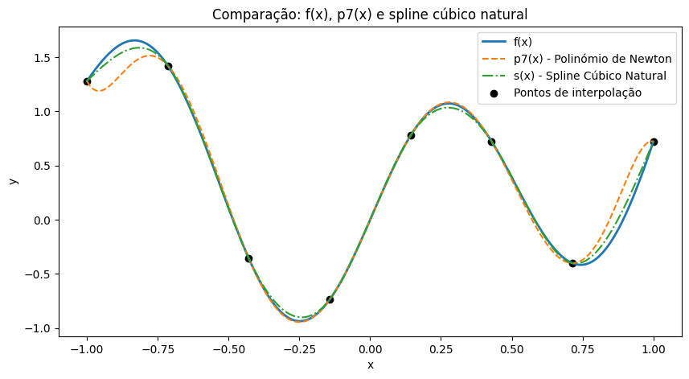

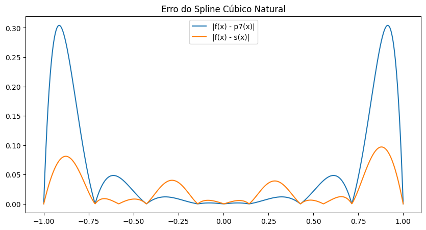

```python
# --- GRÁFICOS DE COMPARAÇÃO ---

xx = np.linspace(a, b, 1000)
f_vals = np.array([f(x) for x in xx])
p_vals = np.array([p7(x) for x in xx])
s_vals = np.array([spline_natural(x) for x in xx])

# --------- Gráfico das aproximações ----------
plt.plot(xx, f_vals, label="f(x)", linewidth=2)
plt.plot(xx, p_vals, label="p7(x) - Polinómio de Newton", linestyle="--")
plt.plot(xx, s_vals, label="s(x) - Spline Cúbico Natural", linestyle="-.")
plt.scatter(x_vals, y_vals, color="black", label="Pontos de interpolação")
plt.title("Comparação: f(x), p7(x) e spline cúbico natural")
plt.xlabel('x'); plt.ylabel('y'); plt.legend(); plt.show()

# --------- Erros absolutos ---------
# Erro |f - p7|, polinómia
plt.plot(xx, np.abs(f_vals - p_vals), label="|f(x) - p7(x)|")
plt.title("Erro do Polinómio Interpolador")
plt.grid(); plt.legend()
# Erro |f - s|, spline
plt.plot(xx, np.abs(f_vals - s_vals), label="|f(x) - s(x)|")
plt.title("Erro do Spline Cúbico Natural")
plt.grid(); plt.legend(); plt.show()
```

### **Comparação entre o polinómio interpolador e o spline cúbico natural**

#### **1. Polinómio interpolador $p_7(x)$**

O *polinómio interpolador* de grau 7 ajusta exatamente os 8 pontos de interpolação.  
No entanto, como é um polinómio global de grau elevado, tende a apresentar oscilações significativas entre os pontos, especialmente perto dos extremos do intervalo $[-1,1]$.  
Este fenómeno é conhecido como **efeito de Runge** e ocorre frequentemente quando se usam pontos uniformemente espaçados.

Como consequência:

- O erro $|f - p|$ aumenta consideravelmente nos extremos.
- A aproximação é menos estável e menos fiel ao comportamento local da função.

#### **2. Spline cúbico natural $s(x)$**

O *spline cúbico natural* é construído como uma coleção de polinómios cúbicos em cada subintervalo, garantindo continuidade das derivadas primeira e segunda.  
Este método evita oscilações indesejadas e adapta-se muito melhor ao comportamento local da função.

#### **3. Comparação gráfica dos erros**

A análise dos gráficos do erro absoluto mostra que:

- O erro do polinómio interpolador $|f - p|$ apresenta picos elevados, sobretudo junto aos extremos.
- O erro do spline cúbico natural $|f - s|$ é reduzido e mantém-se consistentemente baixo ao longo de todo o intervalo.

### **Conclusão**

O **spline cúbico natural** fornece uma aproximação **muito mais estável** e **precisa** da função do que o **polinómio interpolador global** de grau elevado. Enquanto o *polinómio* tenta ajustar todos os pontos com um único polinómio de grau elevado—tornando-se oscilatório—o *spline* utiliza aproximações locais suaves, resultando numa interpolação *mais fiel* e com *menor erro*.

#### **(c) Majorantes dos erros em 𝑥 = 0.1 e 𝑥 = 0.9**

Pretende‑se calcular **majorantes dos erros** cometidos ao estimar os valores de $f(0.1)$ e $f(0.9)$ usando o *polinómio interpolador* $p_7$ e o *spline cúbico natural* $s$.

Para o *polinómio interpolador*, aplicamos o **teorema do erro na interpolação polinomial** apresentado nas aulas teóricas. Como $f\in C^{8}([-1,1])$, existe, para cada $x\in[-1,1]$, um ponto $c(x)$ tal que $$ f(x) - p_7(x) = \frac{f^{(8)}(c(x))}{8!}\,(x-x_0)\cdots(x-x_7). $$ Daqui resulta a estimativa $$ |f(x) - p_7(x)| \leq \frac{\max_{t\in[-1,1]}|f^{(8)}(t)|}{8!}\,\prod_{i=0}^{7}|x-x_i|. $$ onde o *fator dominante no comportamento do erro* é precisamente o produto $\prod_{i=0}^{7}(x-x_i)$.

No caso do *spline cúbico natural*, usa‑se a **forma geral do erro** para *splines cúbicos naturais*, que envolve a *quarta derivada* de $f$. Para $x\in[x_i,x_{i+1}]$, tem‑se $$ f(x) - s(x) = \frac{5f^{(4)}(\eta(x))h^4}{384}, $$ para algum $(\eta(x)\in[x_i,x_{i+1}])$, onde $h = \max_{i=1,2,...,n}\bigl[h_i]$ e $h_i = x_i - x_{i-1}$ donde se obtém a majorante

$$ |f(x) - s(x)| \leq \frac{5\max_{t\in[-1,1]}|f^{(4)}(t)|h^4}{384}\ $$

Temos que: $ f^{(4)} = 6^4sin(6x) = 1296\sin(6x) $ e $ f^{(8)} = 6^8\sin(6x) = 1679616\sin(6x) $

De seguida, recorre‑se à avaliação direta de $(f)$, $(p_7)$ e $(s)$, para obter majorantes e erros efetivos em $(x=0{,}1)$ e $(x=0{,}9)$.

```python
def dx4_f(x): return 6**4*math.sin(6*x)         #1296sin(6x)
def dx8_f(x): return 6**8*math.sin(6*x)         #1679616sin(6x)

# Estimar max |f^(8)(x)| e max |f^(4)(x)| em [-1,1]
xs_grid = np.linspace(-1, 1, 401)

M4 = max(abs(dx4_f(x)) for x in xs_grid)
M8 = max(abs(dx8_f(x)) for x in xs_grid)

print(f"Estimativa de max |f^(8)(x)| em [-1,1] ≈ {M8:.3e}")
print(f"Estimativa de max |f^(4)(x)| em [-1,1] ≈ {M4:.3e}\n")


def prod_term(x, nodes):
    p = 1.0
    for xi in nodes: p *= (x - xi)
    return p

for xv in [0.1, 0.9]:
    fx = f(xv); px = p7(xv); sx = spline_natural(xv)
    err_p = abs(fx - px); err_s = abs(fx - sx)
    # majorante polinómio
    prod_val = abs(prod_term(xv, x_vals))
    maj_p = M8 * prod_val / math.factorial(8)
    # majorante spline: escolher intervalo [x_i, x_{i+1}] que contém xv
    if xv <= x_vals[0]: i = 0
    elif xv >= x_vals[-1]: i = len(x_vals) - 2
    else: i = np.searchsorted(x_vals, xv) - 1

    h = x_vals[i+1] - x_vals[i]
    maj_s = (5/384) * (h**4) * M4

    print(f"x = {xv}")
    print(f"  f(x)  = {fx: .8f}")
    print(f"  p7(x) = {px: .8f},  erro = {err_p: .3e},  majorante ≈ {maj_p: .3e}")
    print(f"  s(x)  = {sx: .8f},  erro = {err_s: .3e},  majorante ≈ {maj_s: .3e}\n")
```

```
Estimativa de max |f^(8)(x)| em [-1,1] ≈ 1.680e+06
Estimativa de max |f^(4)(x)| em [-1,1] ≈ 1.296e+03

x = 0.1
  f(x)  =  0.57464247
  p7(x) =  0.57322495,  erro =  1.418e-03,  majorante ≈  3.729e-02
  s(x)  =  0.58019052,  erro =  5.548e-03,  majorante ≈  1.125e-01

x = 0.9
  f(x)  =  0.03723551
  p7(x) =  0.33653932,  erro =  2.993e-01,  majorante ≈  1.173e+00
  s(x)  =  0.13147543,  erro =  9.424e-02,  majorante ≈  1.125e-01
```

## **Análise Comparativa com Valores Exatos**

### **1. Para x = 0.1 (próximo do centro do intervalo)**

- **Polinómio p7**: Erro real é **pequeno** (1.418e-03), mas o majorante (3.729e-02) superestima em **26×**
- **Spline cúbico**: Erro real (5.548e-03) é maior que o do polinómio, e o majorante (1.125e-01) superestima em **20×**
- **Conclusão**: O polinómio é mais preciso no centro, mas ambos os majorantes são conservadores

### **2. Para x = 0.9 (próximo da extremidade)**

- **Polinómio p7**: Erro real é **muito grande** (0.2993) devido ao fenómeno de Runge, mas o majorante (1.173e+00) superestima apenas **3.9×**
- **Spline cúbico**: Erro (0.09424) é significativamente menor que o do polinómio, e o majorante (1.125e-01) superestima apenas **1.19×**
- **Conclusão**: O spline é muito mais preciso nas extremidades, e sua estimativa de erro é quase exata

### **Comparação de Precisão:**

- Em x=0.1: Polinómio **3.9× mais preciso** que o spline
- Em x=0.9: Spline **3.2× mais preciso** que o polinómio

## **Conclusão Geral**

Para interpolação em todo o intervalo [-1,1], o spline cúbico é preferível devido à sua consistência e estimativas de erro confiáveis.

## **Exercício 2**

#### **(a)**

Considerando o conjunto de dados correspondente às médias mensais da evaporação da água (em polegadas) em Adelaide, ao longo de 23 anos, fornecido no enunciado sob a forma de 12 pares ((x_i,f(x_i))), onde (x_i) representa o mês (de 1 a 12) e (f(x_i)) o valor médio de evaporação nesse mês. Assim, trabalhou‑se com os pontos

$$ x_i = 1,2,\dots,12,\quad f(x_i) \in \{8{,}6,\;7{,}0,\;6{,}4,\;4{,}0,\;2{,}8,\;1{,}8,\;1{,}8,\;2{,}1,\;3{,}2,\;4{,}7,\;6{,}2,\;7{,}6\}. $$

Este conjunto de 12 pontos define uma função discreta que se pretende aproximar por um *polinómio interpolador global* e por um *spline cúbico natural*, de forma a estudar o *comportamento sazonal da evaporação* ao longo do ano.

Com base nesses dados, construímos o *polinómio interpolador* $p(x)$ de grau 11 recorrendo ao **método de Newton** em *diferenças divididas*. Para isso, geramos a tabela de diferenças divididas $\,f[x_i,\dots,x_j]\,$ e extraímos os coeficientes $$ c_0=f[x_1],\;c_1=f[x_1,x_2],\;\dots,\;c_{11}=f[x_1,\dots,x_{12}], $$
que permitem escrever o polinómio na forma de *Newton*, $$ p(x)=c_0+c_1(x-x_1)+c_2(x-x_1)(x-x_2)+\dots+c_{11}(x-x_1)\cdots(x-x_{11}). $$

De seguida, utilizando o mesmo conjunto de pontos, construímos o spline cúbico natural $(s)$. Considerabdo um *spline* $s$ tal que, em cada subintervalo $[x_i,x_{i+1}]$, coincide com um *polinómio cúbico* $S_i(x)$, com continuidade da função e das suas derivadas primeira e segunda nos nós interiores, e impondo ainda as *condições naturais* $s''(x_1)=s''(x_{12})=0$. Para isso, montou‑se o *sistema tridiagonal clássico* para os valores $M_i = s"(x_i)$, $i=1,\dots,12$, o qual foi resolvido numericamente, e a partir dos $M_i$ determinaram‑se os coeficientes $a_i,b_i,c_i,d_i$ dos *polinómios cúbicos* que definem $s(x)$ em cada intervalo $[x_i,x_{i+1}]$.

Por fim, representamos graficamente, no intervalo $x\in[1,12]$, os dados experimentais, a aproximação *polinomial* $p(x)$ e o *spline cúbico natural* $s(x)$, de modo a comparar visualmente o comportamento das duas aproximações da função de evaporação ao longo do ano.

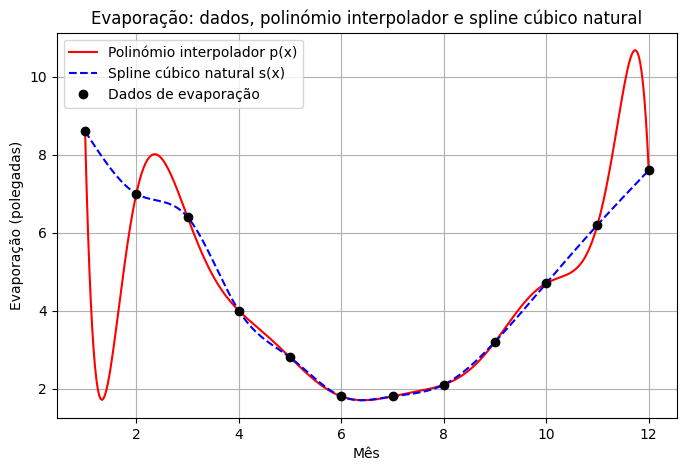

```python
# Dados do enunciado (meses e evaporação) [file:2]
x_mes = np.arange(1, 13, dtype=float)  # 1,...,12
y_evap = np.array([8.6, 7.0, 6.4, 4.0, 2.8, 1.8, 1.8, 2.1, 3.2, 4.7, 6.2, 7.6])

# --- Polinómio interpolador p(x) por Newton (diferenças divididas) ---

m = len(x_mes)
DD = [[0.0 for _ in range(m)] for _ in range(m)]
for i in range(m): DD[i][0] = y_evap[i]
for j in range(1, m):
    for i in range(m - j):
        DD[i][j] = (DD[i+1][j-1] - DD[i][j-1]) / (x_mes[i+j] - x_mes[i])

coeffs_p = [DD[0][j] for j in range(m)]  # c0,...,c11

def p_interp(x):
    """Avalia o polinómio interpolador p(x) de grau <=11 em x."""
    value = 0.0
    term = 1.0
    for j in range(m):
        value += coeffs_p[j] * term
        term *= (x - x_mes[j])
    return value

# --- Spline cúbico natural s(x) nos 12 pontos ---

n = m - 1                    # 11 intervalos
h = np.diff(x_mes)           # aqui h_i = 1 para todos, mas escrevemos em geral

A = np.zeros((m, m))
b_vec = np.zeros(m)

# Condições naturais: M_1 = 0, M_12 = 0
A[0, 0] = 1.0
A[m-1, m-1] = 1.0
b_vec[0] = 0.0
b_vec[m-1] = 0.0

for i in range(1, m-1):
    hi = h[i-1]
    hi1 = h[i]
    A[i, i-1] = hi
    A[i, i]   = 2*(hi + hi1)
    A[i, i+1] = hi1
    b_vec[i]  = 6 * ((y_evap[i+1] - y_evap[i]) / hi1 - (y_evap[i] - y_evap[i-1]) / hi)

M = np.linalg.solve(A, b_vec)   # M[i] = s''(x_i)

# Coeficientes dos cúbicos S_i(x) em cada [x_i, x_{i+1}]
coefs_s = []
for i in range(n):
    hi = x_mes[i+1] - x_mes[i]
    a_i = y_evap[i]
    c_i = M[i] / 2.0
    d_i = (M[i+1] - M[i]) / (6.0 * hi)
    b_i = (y_evap[i+1] - y_evap[i]) / hi - (2*M[i] + M[i+1]) * hi / 6.0
    coefs_s.append((a_i, b_i, c_i, d_i))

def s_spline(x):
    """Avalia o spline cúbico natural s(x) nos dados de evaporação."""
    if x <= x_mes[0]: i = 0
    elif x >= x_mes[-1]: i = n-1
    else: i = np.searchsorted(x_mes, x) - 1
    a_i, b_i, c_i, d_i = coefs_s[i]
    dx = x - x_mes[i]
    return a_i + b_i*dx + c_i*dx**2 + d_i*dx**3

# --- Gráficos p(x), s(x) e pontos de dados ---

xs_plot = np.linspace(1, 12, 400)
p_vals = [p_interp(x) for x in xs_plot]
s_vals = [s_spline(x) for x in xs_plot]

plt.figure(figsize=(8, 5))
plt.plot(xs_plot, p_vals, 'r-', label='Polinómio interpolador p(x)')
plt.plot(xs_plot, s_vals, 'b--', label='Spline cúbico natural s(x)')
plt.plot(x_mes, y_evap, 'ko', label='Dados de evaporação')
plt.xlabel('Mês')
plt.ylabel('Evaporação (polegadas)')
plt.title('Evaporação: dados, polinómio interpolador e spline cúbico natural')
plt.legend()
plt.grid(True)
plt.show()
```

Em seguida, utilizando o mesmo conjunto de 12 pontos, construímos o *spline cúbico natural* $s(x)$. Considerou‑se um *spline cúbico* tal que, em cada subintervalo $[x_i,x_{i+1}]$, coincide com um *polinómio cúbico* $$ S_i(x)=a_i+b_i(x-x_i)+c_i(x-x_i)^2+d_i(x-x_i)^3,\quad i=1,\dots,11, $$ com continuidade de $(s)$, $(s')$ e $(s'')$ nos nós interiores e impondo ainda as condições naturais $(s''(x_1)=s''(x_{12})=0)$.

Para determinar o *spline*, montamos o sistema *tridiagonal clássico* para os valores $M_i=s''(x_i)$, $i=1,\dots,12$, cujos coeficientes dependem dos espaçamentos $h_i=x_{i+1}-x_i$ e dos incrementos nos valores de $f$. Este sistema linear foi resolvido numericamente com `numpy.linalg.solve`, obtendo‑se os $M_i$ que garantem, simultaneamente, a continuidade da primeira derivada e a condição natural de anulamento da segunda derivada nos extremos do intervalo temporal.

A partir dos valores $M_i$, calcularam‑se então, para cada subintervalo $[x_i,x_{i+1}]$, os coeficientes $a_i,b_i,c_i,d_i$ das expressões padrão do *spline cúbico natural*, de acordo com as fórmulas teóricas estudadas nas aulas. No programa, estes coeficientes foram guardados numa lista e definímos uma função `sspline(x)` que, dado um mês $x$, identifica o intervalo correspondente e avalia o polinómio cúbico $S_i(x)$, definindo assim $s(x)$ em todo o intervalo $[1,12]$.

Por fim, representamos graficamente, no intervalo $x\in[1,12]$, os dados experimentais, o *polinómio interpolador* $p(x)$ e o *spline cúbico natural* $s(x)$. O gráfico obtido permite uma comparação visual imediata entre os valores medidos e as duas aproximações interpolantes, ilustrando as diferenças de comportamento entre a interpolação polinomial global de alto grau e a interpolação polinomial segmentada por splines cúbicos naturais.

#### **(b)**

A partir do gráfico construído na alínea (a), observa‑se que o *polinómio interpolador* $p(x)$ passa exatamente pelos 12 pontos de dados, como garante o teorema de existência e unicidade do *polinómio interpolador* de grau $n$ em $n+1$ pontos de abcissas distintas. No entanto, entre alguns meses o polinómio apresenta *oscilações acentuadas* e *variações bruscas de concavidade*, especialmente nas regiões em que os valores de evaporação mudam mais rapidamente, o que é um comportamento *típico* de polinómios de grau elevado sujeito ao chamado **fenómeno de Runge**.

Por outro lado, o *spline cúbico natural* $s(x)$ fornece uma *curva suave* que se *ajusta bem* aos dados experimentais, acompanhando de forma *gradual* a descida da evaporação entre os meses de verão e inverno e o aumento posterior até ao final do ano. A *curva do spline* **não** introduz *oscilações artificiais* entre os nós, preservando *melhor* a forma global da série temporal e originando uma evolução sazonal mais regular e coerente com o comportamento físico do fenómeno em estudo.

Deste modo, conclui‑se que, para estes dados de evaporação, a aproximação *mais aceitável* é a fornecida pelo **spline cúbico natural** $s(x)$, que combina a *interpolação exata* dos pontos com um comportamento *muito mais estável* entre os nós. Esta conclusão está em consonância com a motivação teórica para o uso de *splines*, onde se realça que, em muitos conjuntos de dados reais, os *splines cúbicos naturais* produzem aproximações mais **fiáveis** e **realistas** do que os *polinómios globais* de grau elevado, mitigando as grandes oscilações fora da vizinhança imediata dos dados.

## **Conclusão**

Neste trabalho estudamos as duas abordagens de *interpolação*, recorrendo a *polinómios globais* obtidos pelo **método de Newton** em *diferenças divididas* e a **splines cúbicos naturais**, aplicadas tanto a funções de teste como a dados reais de evaporação. Observamos que os *polinómios de grau elevado* podem introduzir oscilações significativas, sobretudo perto dos extremos do intervalo, enquanto os *splines cúbicos naturais* fornecem aproximações mais estáveis e visualmente mais próximas do comportamento esperado das funções e dos dados. A análise dos erros teóricos e numéricos confirmou estas conclusões, mostrando que, para muitos problemas práticos, os **splines cúbicos naturais** constituem uma alternativa mais **fiável** do que a *interpolação polinomial global*.